# hw6

Charles Yang

10/13/2021

1. Concept Review

1.1 Lasso vs. Ridge Coefficients

Lasso can set coefficients to zero in regression because of its penalty term. Ridge uses a parabola (beta^2) as it's penalty term, and Lasso uses an absolute value function. The penalty acts as a constraint for coefficient values. These constraints are shaped differently. As we increase the allowable error (RSS) in our model, the possible values of coefficients expand from what they would be without a penalty term. As we can see in the figure, ridge coefficients (right figure) will reach inside its circle shaped constraintbefore any coefficient can be zero. However, because Lasso uses an absolute value, it's constraint is shaped like a diamond, making it possible (and far easier) for the minimized Lasso value to occur at a coefficient of zero.

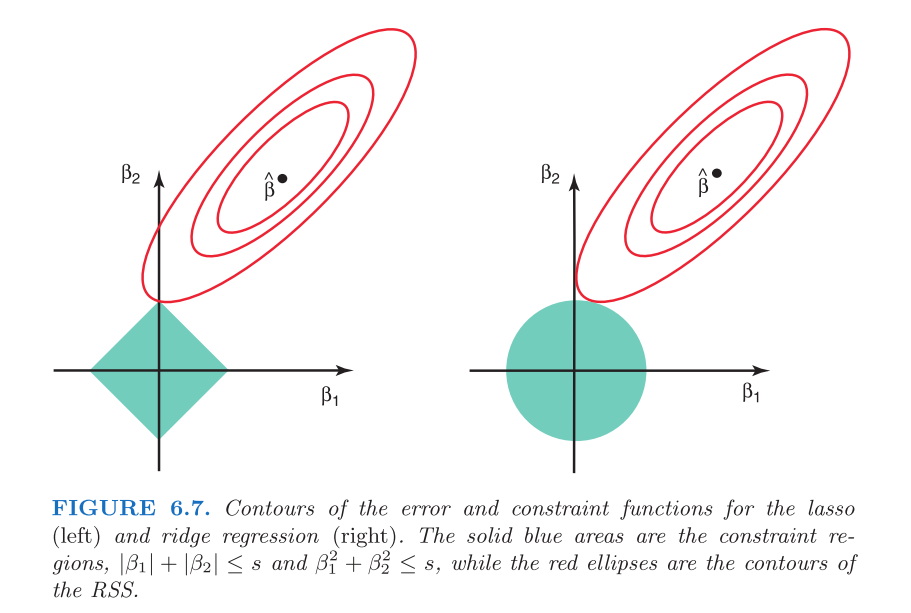

2. Building a predictive model

```r
n = nrow(Boston)
vars = names(Boston)
vars.length = length(vars)

# Generating interaction and 2nd degree polynomial terms
for (i in 2:(vars.length - 1)) {
  for (j in (i+1):vars.length) {
    Boston <- cbind(Boston, Boston[,i] * Boston[,j])
    names(Boston)[ncol(Boston)] <- paste0(vars[i], "*", vars[j])
  }
}
for (i in 2:vars.length) {
  Boston <- cbind(Boston, Boston[,i]^2)
  names(Boston)[ncol(Boston)] <- paste0(vars[i], "^2")
}

# Get train and test set
test_index = sample(1:n, n/10, replace=FALSE)
test = Boston[test_index,]
train = Boston[-test_index,]

# Scatter matrix
# pairs(Boston)
```

```r
# Utility function for printing out regression equations
printEquation = function(reg_fit, which_var, dependent_var) {
  cc = coef(reg_fit, which_var)
  eqn = paste(dependent_var, "=", paste(round(cc[1],4), paste(round(cc[-1],4), names(cc[-1]), sep=" * ", collapse=" + "), sep=" + "))
  (eqn = gsub('\\+ -', '- ', gsub(' \\* ', '*', eqn)))
}

# forward stepwise selection on all transformed training data
regfit.fwd = regsubsets(log(crim)~., data=train, nvmax=ncol(train) - 1, method="forward")
```

```
## Reordering variables and trying again:
```

```r
regfit.fwd.sum = summary(regfit.fwd)

p = rowSums(regfit.fwd.sum$which)
rss = regfit.fwd.sum$rss

fwd.BIC = n*log(rss/n) + p*log(n)

#printEquation(regfit.fwd, which.min(fwd.BIC), "log(crim)")

fwd.selected = train[, regfit.fwd.sum$which[which.min(fwd.BIC),]]
regfit.fwd.best = lm(log(crim)~., data=fwd.selected)
regfit.fwd.best.sum = summary(regfit.fwd.best)
regfit.fwd.best.sum
```

```
##
## Call:
## lm(formula = log(crim) ~ ., data = fwd.selected)
##
## Residuals:
##      Min       1Q   Median       3Q      Max
## -1.74637 -0.37978 -0.01376  0.33342  2.68326
##
## Coefficients:
##                   Estimate Std. Error t value Pr(>|t|)
## (Intercept)      3.797e+00  3.045e+00   1.247 0.213042
## zn               1.246e-01  3.464e-02   3.597 0.000359 ***
## nox              5.208e+00  9.967e-01   5.225 2.73e-07 ***
## age             -2.054e-02  6.023e-03  -3.409 0.000713 ***
## dis             -1.463e+00  2.581e-01  -5.669 2.65e-08 ***
## rad              1.046e+00  2.375e-01   4.405 1.34e-05 ***
## ptratio         -9.326e-01  2.970e-01  -3.140 0.001808 **
## `zn*rm`         -9.418e-03  3.086e-03  -3.052 0.002419 **
## `zn*rad`         9.664e-04  1.130e-03   0.855 0.392973
## `zn*ptratio`    -4.422e-03  1.197e-03  -3.693 0.000251 ***
## `indus*dis`     -8.313e-04  5.507e-03  -0.151 0.880081
## `indus*tax`      5.028e-04  8.636e-05   5.822 1.15e-08 ***
## `nox*rad`       -3.490e-01  6.760e-02  -5.162 3.76e-07 ***
## `age*rad`       -1.565e-04  3.739e-04  -0.419 0.675690
## `dis*rad`       -5.643e-02  8.260e-03  -6.832 2.90e-11 ***
## `dis*tax`        1.472e-03  3.035e-04   4.850 1.73e-06 ***
## `dis*ptratio`    6.350e-02  1.227e-02   5.174 3.52e-07 ***
## `dis*medv`       6.399e-03  2.505e-03   2.555 0.010969 *
## `rad*ptratio`   -1.960e-02  1.183e-02  -1.657 0.098217 .
## `rad*medv`      -2.650e-03  9.720e-04  -2.726 0.006669 **
## `tax*lstat`     -2.355e-04  5.166e-05  -4.560 6.70e-06 ***
## `tax*medv`       6.512e-05  3.537e-05   1.841 0.066294 .
## `ptratio*lstat`  8.894e-03  1.744e-03   5.100 5.12e-07 ***
## `lstat*medv`    -3.173e-03  7.278e-04  -4.359 1.64e-05 ***
## `indus^2`       -4.384e-03  7.613e-04  -5.759 1.62e-08 ***
## `age^2`          2.157e-04  5.489e-05   3.931 9.88e-05 ***
## `tax^2`         -1.625e-05  2.977e-06  -5.457 8.22e-08 ***
## `ptratio^2`      2.059e-02  8.594e-03   2.396 0.016992 *
## `lstat^2`        3.217e-04  6.985e-04   0.460 0.645403
## ---
## Signif. codes:  0 '***' 0.001 '**' 0.01 '*' 0.05 '.' 0.1 ' ' 1
##
## Residual standard error: 0.596 on 427 degrees of freedom
## Multiple R-squared:  0.928,  Adjusted R-squared:  0.9233
## F-statistic: 196.7 on 28 and 427 DF,  p-value: < 2.2e-16
```

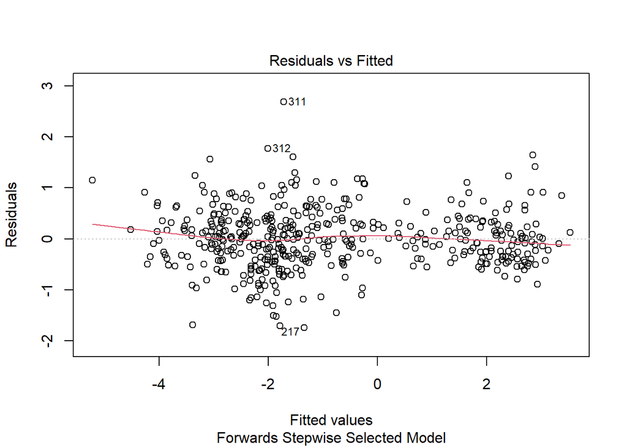

```r
plot(regfit.fwd.best, which=1, sub="Forwards Stepwise Selected Model")
```

```r
# backwards
regfit.bwd = regsubsets(log(crim)~., data=train, nvmax=ncol(train) - 1, method="backward")
```

```
## Reordering variables and trying again:
```

```r
regfit.bwd.sum = summary(regfit.bwd)

p = rowSums(regfit.bwd.sum$which)
rss = regfit.bwd.sum$rss

bwd.BIC = n*log(rss/n) + p*log(n)

#printEquation(regfit.bwd, which.min(bwd.BIC), "log(crim)")

bwd.selected = train[, regfit.bwd.sum$which[which.min(bwd.BIC),]]
regfit.bwd.best = lm(log(crim)~., data=bwd.selected)
regfit.bwd.best.sum = summary(regfit.bwd.best)
regfit.bwd.best.sum
```

```
##
## Call:
## lm(formula = log(crim) ~ ., data = bwd.selected)
##
## Residuals:
##      Min       1Q   Median       3Q      Max
## -1.40258 -0.35986 -0.02677  0.35808  2.00271
##
## Coefficients:
##                   Estimate Std. Error t value Pr(>|t|)
## (Intercept)      1.068e+01  4.500e+00   2.372 0.018129 *
## indus           -9.872e-01  1.455e-01  -6.783 4.06e-11 ***
## chas            -7.082e+00  1.823e+00  -3.885 0.000119 ***
## nox              6.559e+01  9.289e+00   7.061 7.02e-12 ***
## age             -9.477e-02  1.316e-02  -7.201 2.82e-12 ***
## dis             -1.985e+00  4.035e-01  -4.919 1.26e-06 ***
## rad              9.645e-01  8.673e-02  11.121  < 2e-16 ***
## tax             -1.723e-02  4.097e-03  -4.205 3.20e-05 ***
## ptratio         -2.122e+00  3.317e-01  -6.399 4.23e-10 ***
## medv            -6.214e-02  1.033e-02  -6.017 3.90e-09 ***
## `zn*nox`         3.026e-01  5.724e-02   5.287 2.02e-07 ***
## `zn*age`        -5.102e-04  1.268e-04  -4.025 6.78e-05 ***
## `zn*dis`         4.207e-03  9.646e-04   4.361 1.63e-05 ***
## `zn*rad`         4.018e-03  1.110e-03   3.619 0.000333 ***
## `zn*tax`        -7.587e-05  2.709e-05  -2.801 0.005329 **
## `zn*ptratio`    -6.502e-03  1.124e-03  -5.787 1.41e-08 ***
## `zn*medv`       -9.853e-04  2.014e-04  -4.891 1.44e-06 ***
## `indus*chas`    -3.174e-01  5.396e-02  -5.883 8.32e-09 ***
## `indus*nox`      2.166e+00  2.448e-01   8.850  < 2e-16 ***
## `indus*dis`      5.196e-02  1.222e-02   4.252 2.62e-05 ***
## `indus*rad`      1.792e-02  7.132e-03   2.513 0.012358 *
## `chas*rad`      -4.757e-01  9.161e-02  -5.193 3.25e-07 ***
## `chas*tax`       3.078e-02  5.384e-03   5.717 2.08e-08 ***
## `chas*ptratio`   2.021e-01  8.705e-02   2.321 0.020754 *
## `nox*dis`       -3.021e+00  6.703e-01  -4.507 8.57e-06 ***
## `nox*rad`       -5.147e-01  6.967e-02  -7.388 8.24e-13 ***
## `rm*age`         4.988e-03  9.817e-04   5.081 5.70e-07 ***
## `rm*lstat`      -2.341e-02  4.807e-03  -4.870 1.59e-06 ***
## `age*dis`        6.686e-03  1.335e-03   5.007 8.19e-07 ***
## `dis*rad`       -8.392e-02  9.661e-03  -8.686  < 2e-16 ***
## `dis*tax`        2.329e-03  3.863e-04   6.029 3.65e-09 ***
## `dis*ptratio`    1.092e-01  1.268e-02   8.610  < 2e-16 ***
## `dis*medv`       1.583e-02  2.862e-03   5.529 5.71e-08 ***
## `rad*tax`       -9.635e-04  2.454e-04  -3.926 0.000101 ***
## `tax*lstat`     -1.884e-04  4.296e-05  -4.385 1.47e-05 ***
## `ptratio*lstat`  1.245e-02  2.041e-03   6.101 2.42e-09 ***
## `indus^2`       -1.403e-02  2.193e-03  -6.398 4.25e-10 ***
## `nox^2`         -6.648e+01  8.036e+00  -8.273 1.79e-15 ***
## `age^2`          3.498e-04  6.145e-05   5.692 2.38e-08 ***
## `tax^2`          1.788e-05  4.621e-06   3.868 0.000127 ***
## `ptratio^2`      4.470e-02  9.244e-03   4.836 1.87e-06 ***
## ---
## Signif. codes:  0 '***' 0.001 '**' 0.01 '*' 0.05 '.' 0.1 ' ' 1
##
## Residual standard error: 0.5499 on 415 degrees of freedom
## Multiple R-squared:  0.9405, Adjusted R-squared:  0.9347
## F-statistic: 163.9 on 40 and 415 DF,  p-value: < 2.2e-16
```

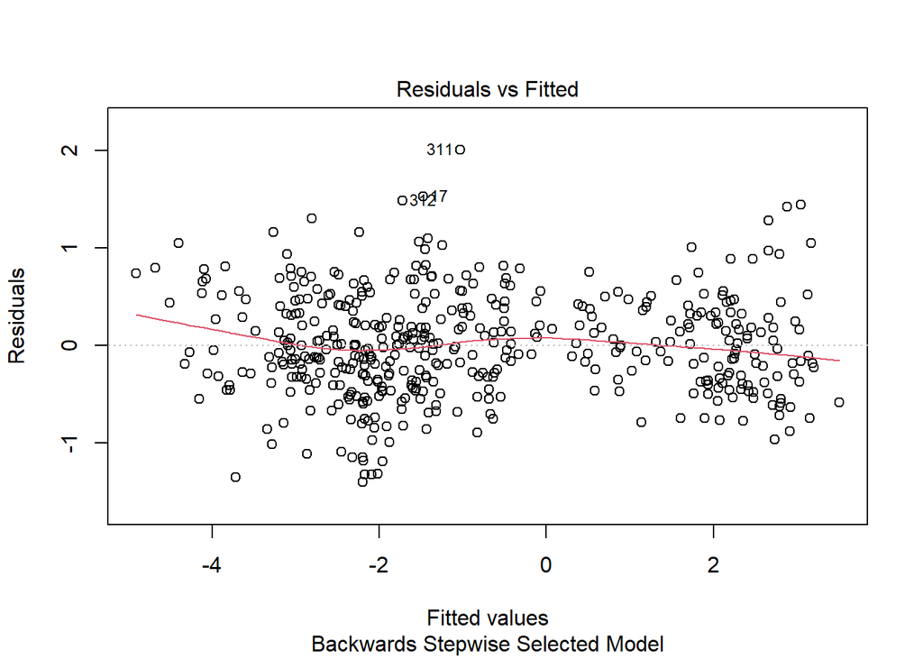

```r
plot(regfit.bwd.best, which=1, sub="Backwards Stepwise Selected Model")
```

2.1 Least-Squares Model

```r
k=10
folds <- createFolds(bwd.selected$crim, k = k, list = TRUE, returnTrain = FALSE)

Fold_MSEs = data.frame()
for (i in 1:k) {
  spline.test_index = folds[[i]]
  spline.test = bwd.selected[spline.test_index,]
  spline.train = bwd.selected[-spline.test_index,]

  MSEs = c()
  for (df in 1:10) {
    spline = lm(crim~.-`indus^2`-`nox^2`-`age^2`-`tax^2`-`ptratio^2` + ns(indus, df = df) + ns(nox, df = df) + ns(age, df = df) + ns(tax, df = df) + ns(ptratio, df = df), data=spline.train)
    spline.predicted = predict(spline, spline.test)

    MSEs = append(MSEs, mean((spline.test$crim - spline.predicted)^2))
  }

  Fold_MSEs = rbind(Fold_MSEs, MSEs)
}
```

```r
for(i in 1:10) {
  print(paste("CV test MSE for model", i, "is", mean(Fold_MSEs[,i])))
}
```

[output not shown]

2.1 Least-Squares Model

To test if splines will improve the model, we can perform cross validation on a cubic spline for every polynomial term selected by backwards stepwise-selection. I chose the backwards stepwise because I felt like it. After finding the best model with a spline, we will test it vs the other models using the test set.  
Best df is 1. This suggests that a spline does not improve the best backwards stepwise model. I won't bother testing it.

```r
grid = 10^seq(10,-2,length=100)
X = model.matrix(log(crim)~., data=train)[,-1]
Y = log(train$crim)
```

```r
ridge.cv = cv.glmnet(X, Y, alpha=0, lambda = grid)
ridge.lambda.best = ridge.cv$lambda.min
ridge.lambda.1se = ridge.cv$lambda.1se
Model2a = glmnet(X, Y, alpha = 0, lambda = ridge.lambda.best)
Model2b = glmnet(X, Y, alpha = 0, lambda = ridge.lambda.1se)

lasso.cv = cv.glmnet(X, Y, alpha = 1, lambda = grid)
lasso.lambda.best = lasso.cv$lambda.min
lasso.lambda.1se = lasso.cv$lambda.1se
Model3a = glmnet(X, Y, alpha = 1, lambda = lasso.lambda.best)
Model3b = glmnet(X, Y, alpha = 1, lambda = lasso.lambda.1se)

coef(Model2a)
```

```
## 91 x 1 sparse Matrix of class "dgCMatrix"
##                            s0
## (Intercept)     -3.540036e+00
## zn               9.140100e-03
## indus            9.165604e-02
## chas            -5.912931e-01
## nox              6.653269e+00
## rm              -3.631272e-01
## age              2.272560e-03
## dis             -2.188726e-01
## rad              1.016895e-01
## tax              2.340489e-03
## ptratio         -9.735294e-02
## lstat            3.068544e-02
## medv             1.808208e-02
## `zn*indus`      -1.425975e-03
## `zn*chas`       -6.523254e-03
## `zn*nox`         1.663165e-02
## `zn*rm`          5.082081e-04
## `zn*age`        -1.100261e-04
## `zn*dis`         1.106946e-03
## `zn*rad`         1.044881e-03
## `zn*tax`         2.386311e-05
## `zn*ptratio`    -1.068517e-03
## `zn*lstat`      -4.417196e-04
## `zn*medv`       -3.927136e-04
## `indus*chas`    -1.212610e-01
## `indus*nox`      4.968728e-02
## `indus*rm`       1.857735e-03
## `indus*age`      5.269446e-04
## `indus*dis`      5.266333e-03
## `indus*rad`      1.129054e-03
## `indus*tax`      1.065471e-04
## `indus*ptratio` -2.590203e-03
## `indus*lstat`   -3.009616e-03
## `indus*medv`    -1.056787e-04
## `chas*nox`       1.363523e+00
## `chas*rm`        1.536952e-01
## `chas*age`      -5.652953e-03
## `chas*dis`      -1.495549e-01
```

[output cut: 38 more lines]

```
## `ptratio*lstat`  4.352866e-03
## `ptratio*medv`  -2.199213e-03
## `lstat*medv`    -2.507582e-03
## `zn^2`          -9.586470e-05
## `indus^2`       -4.112930e-03
## `chas^2`        -5.035283e-01
## `nox^2`          1.401848e+00
## `rm^2`           4.260666e-02
## `age^2`          2.146925e-04
## `dis^2`         -5.251017e-04
## `rad^2`          1.876346e-04
## `tax^2`         -4.711004e-06
## `ptratio^2`      9.991187e-03
## `lstat^2`        1.347506e-04
## `medv^2`         1.409742e-04
```

```r
coef(Model2b)
```

```
## 91 x 1 sparse Matrix of class "dgCMatrix"
##                            s0
## (Intercept)     -2.925008e+00
## zn               3.359233e-03
## indus            2.506453e-02
## chas             3.576583e-02
## nox              2.852465e+00
## rm              -1.718391e-01
## age              2.795351e-03
## dis             -1.068979e-01
## rad              6.415343e-02
## tax              1.448495e-03
## ptratio         -2.359138e-02
## lstat            3.105128e-02
## medv            -2.666862e-03
## `zn*indus`      -1.511102e-03
## `zn*chas`       -3.820724e-03
## `zn*nox`         1.031076e-02
## `zn*rm`         -1.782451e-04
## `zn*age`        -7.310578e-05
## `zn*dis`         5.757722e-04
## `zn*rad`         4.761855e-04
## `zn*tax`         2.376973e-05
## `zn*ptratio`    -4.427451e-04
## `zn*lstat`      -5.246983e-04
## `zn*medv`       -2.481407e-04
## `indus*chas`    -6.827120e-02
## `indus*nox`      2.085437e-02
## `indus*rm`       5.314893e-03
## `indus*age`      3.598747e-04
## `indus*dis`      3.354483e-03
## `indus*rad`      2.103213e-03
## `indus*tax`      5.443853e-05
## `indus*ptratio` -5.620472e-04
## `indus*lstat`   -1.386618e-03
## `indus*medv`     6.758686e-04
## `chas*nox`       1.000630e+00
## `chas*rm`        7.294792e-02
## `chas*age`      -2.415275e-03
## `chas*dis`      -9.564955e-02
```

[output cut: 38 more lines]

```
## `ptratio*lstat`  2.317597e-03
## `ptratio*medv`  -2.202020e-03
## `lstat*medv`    -2.074709e-03
## `zn^2`          -7.266250e-05
## `indus^2`       -3.763247e-03
## `chas^2`         1.270044e-02
## `nox^2`          7.674523e-01
## `rm^2`           1.901205e-02
## `age^2`          1.494056e-04
## `dis^2`          1.362929e-03
## `rad^2`          3.404238e-04
## `tax^2`         -2.142098e-06
## `ptratio^2`      5.708496e-03
## `lstat^2`        3.288618e-04
## `medv^2`         3.310347e-04
```

```r
coef(Model3a)
```

```
## 91 x 1 sparse Matrix of class "dgCMatrix"
##                            s0
## (Intercept)     -4.022234e+00
## zn               .
## indus            .
## chas             .
## nox              3.417272e+00
## rm               .
## age              .
## dis              .
## rad              1.276302e-01
## tax              .
## ptratio          .
## lstat            .
## medv             .
## `zn*indus`      -1.295134e-03
## `zn*chas`        .
## `zn*nox`         .
## `zn*rm`          .
## `zn*age`        -6.813738e-05
## `zn*dis`         .
## `zn*rad`         .
## `zn*tax`         .
## `zn*ptratio`     .
## `zn*lstat`       .
## `zn*medv`       -6.809819e-05
## `indus*chas`     .
## `indus*nox`      .
## `indus*rm`       .
## `indus*age`      .
## `indus*dis`      7.046992e-03
## `indus*rad`      .
## `indus*tax`      .
## `indus*ptratio`  .
## `indus*lstat`    .
## `indus*medv`     1.919975e-03
## `chas*nox`       .
## `chas*rm`        1.587781e-02
## `chas*age`       .
## `chas*dis`       .
```

[output cut: 38 more lines]

```
## `ptratio*lstat`  1.137115e-03
## `ptratio*medv`  -2.006589e-03
## `lstat*medv`    -1.299176e-03
## `zn^2`          -3.242157e-05
## `indus^2`       -1.995881e-03
## `chas^2`         .
## `nox^2`          .
## `rm^2`           .
## `age^2`          1.246120e-04
## `dis^2`          .
## `rad^2`          .
## `tax^2`         -2.772982e-07
## `ptratio^2`      .
## `lstat^2`        6.541406e-04
## `medv^2`         3.962846e-04
```

```r
coef(Model3b)
```

```
## 91 x 1 sparse Matrix of class "dgCMatrix"
##                            s0
## (Intercept)     -4.049372e+00
## zn               .
## indus            .
## chas             .
## nox              2.399741e+00
## rm               .
## age              .
## dis              .
## rad              1.420284e-01
## tax              .
## ptratio          .
## lstat            .
## medv             .
## `zn*indus`      -7.448294e-04
## `zn*chas`        .
## `zn*nox`         .
## `zn*rm`          .
## `zn*age`        -1.505960e-04
## `zn*dis`         .
## `zn*rad`         .
## `zn*tax`         .
## `zn*ptratio`     .
## `zn*lstat`       .
## `zn*medv`       -2.094522e-05
## `indus*chas`     .
## `indus*nox`      .
## `indus*rm`       .
## `indus*age`      .
## `indus*dis`      1.564932e-03
## `indus*rad`      .
## `indus*tax`      .
## `indus*ptratio`  .
## `indus*lstat`    .
## `indus*medv`     1.158741e-03
## `chas*nox`       .
## `chas*rm`        .
## `chas*age`       .
## `chas*dis`       .
```

[output cut: 38 more lines]

```
## `ptratio*lstat`  .
## `ptratio*medv`  -6.293798e-04
## `lstat*medv`    -5.652501e-04
## `zn^2`          -4.164191e-05
## `indus^2`       -6.210631e-04
## `chas^2`         .
## `nox^2`          .
## `rm^2`           .
## `age^2`          9.294949e-05
## `dis^2`          .
## `rad^2`          .
## `tax^2`          .
## `ptratio^2`      .
## `lstat^2`        9.842858e-04
## `medv^2`         .
```

2.2+3 Ridge and Lasso

See output above for the models. Forgive me, for I don't know a better way to display these

```r
X.test = model.matrix(log(crim)~., data=test)
Y.test = log(test$crim)

fwd.test.MSE = mean((predict(regfit.fwd.best, newdata=test) - Y.test)^2)
bwd.test.MSE = mean((predict(regfit.bwd.best, newdata=test) - Y.test)^2)
ridge.test.MSE = mean((predict(Model2a, s = ridge.lambda.best, newx=X.test[,-1]) - Y.test)^2)
lasso.test.MSE = mean((predict(Model3a, s = lasso.lambda.best, newx=X.test[,-1]) - Y.test)^2)

fwd.test.MSE
```

```
## [1] 0.4088436
```

```r
bwd.test.MSE
```

```
## [1] 0.5716224
```

```r
ridge.test.MSE
```

```
## [1] 0.4890718
```

```r
lasso.test.MSE
```

```
## [1] 0.527313
```

2.4 Final Model

I choose my best forward stepwise selected model because it has the lowest test MSE of 0.4088. It does not contain all features because some are probably not useful in making predictions. If it was the ridge regression, then it would contain all variables because it can't physically set coefficients to 0.

3. Bootstrap

```r
# Fixing dataset
Boston = Boston[,1:13]
```

```r
(mu_hat = mean(Boston$medv))
```

```
## [1] 22.53281
```

```r
(se_hat = sd(Boston$medv)/sqrt(length(Boston$medv)))
```

```
## [1] 0.4088611
```

3a+b Mean and Standard Error

Estimate mean and standard error as 22.53 and 0.409, respectively. The typical difference between the sample mean and population mean is 0.409. The variability seems low.

```r
B = 1000
b.means = rep(0,B)
n = dim(Boston)[1]
for(i in 1:B){
    index = sample(1:n,n,replace=TRUE)
    bootsample = Boston[index,]
    b.means[i] = mean(bootsample$medv)
}

(b.mean = mean(b.means))
```

```
## [1] 22.55524
```

```r
(b.se = sqrt(sum((b.means-b.mean)^2)/(B-1)))
```

```
## [1] 0.4115709
```

3c Bootstrap mean

The mean and standard error acquried from bootstrap are extremely similar to their siblings obtained from analytical formulas.

```r
n = nrow(Boston)
B = 500
m = 100
Fstar = rep(0,B)
b.means = rep(0,m)
```

```r
b.mean.star = mean(Boston$medv)
b.se.star = sd(Boston$medv)/sqrt(length(Boston$medv))
```

```r
for(b in 1:B){
  index = sample(1:n,n,replace=TRUE)
  b.mean.hat = mean(Boston$medv[index])
  for(i in 1:m){
    index2 = sample(index,n,replace=TRUE)
    bootsample2 = Boston$medv[index2]
    b.means[i] = mean(bootsample2)
  }
  b.se.means = sqrt(sum((b.means-mean(b.means))^2)/(m-1))

  Fstar[b] = (b.mean.hat - b.mean.star)/b.se.means
}
print("Bootstrap CI:")
```

```
## [1] "Bootstrap CI:"
```

```r
quantile(Fstar,c(0.025, 0.975))
```

```
##      2.5%     97.5%
## -2.093553  1.997532
```

```r
b.mean.star + quantile(Fstar, 0.025)*b.se.star
```

```
##     2.5%
## 21.67683
```

```r
b.mean.star + quantile(Fstar, 0.975)*b.se.star
```

```
##    97.5%
## 23.34952
```

```r
print("Analytical CI:")
```

```
## [1] "Analytical CI:"
```

```r
b.mean.star + qt(0.975, df=n-1)*b.se.star
```

```
## [1] 23.33608
```

```r
b.mean.star + qt(0.025, df=n-1)*b.se.star
```

```
## [1] 21.72953
```

3d Bootstrap mean CI

The CIs are very similar, but the bootstrapped interval is not symmetrical around the mean. This is because bootstrap does not assume the distribution is normal (and symmetrical).

```r
B = 1000
bootstrap.median = rep(0,B)
n = dim(Boston)[1]
for(i in 1:B){
    index = sample(1:n,n,replace=TRUE)
    bootsample = Boston[index,]
    bootstrap.median[i] = median(bootsample$medv)
}
b.median = mean(bootstrap.median)
paste("Bootstrapped Median:",b.median)
```

```
## [1] "Bootstrapped Median: 21.17525"
```

```r
paste("Bootstrapped SE of Median:", sqrt(sum((bootstrap.median-b.median)^2)/(B-1)))
```

```
## [1] "Bootstrapped SE of Median: 0.369237421957436"
```

```r
bootstrap_10 = rep(0,B)
n = dim(Boston)[1]
for(i in 1:B){
    index = sample(1:n,n,replace=TRUE)
    bootsample = Boston[index,]
    bootstrap_10[i] = quantile(bootsample$medv,0.10)
}

b.10p = mean(bootstrap_10)
paste("Bootstrapped SE of 10th percentile of medv", b.10p)
```

```
## [1] "Bootstrapped SE of 10th percentile of medv 12.74135"
```

```r
paste("Bootstrapped SE of 10th percentile of medv", sqrt(sum((bootstrap_10-b.10p)^2)/(B-1)))
```

```
## [1] "Bootstrapped SE of 10th percentile of medv 0.495664564863034"
```

3e-h Bootstrap median

The standard error of the tenth percentile is slightly higher compared to that of the median. The bootstrapped median is slightly smaller than the mean as expected because medv is right skewed.

4. Properties of Bootstrap

a. n = number of observations in the original and bootstrap sample. If we simply pick one observation, the odds of it being a single jth observation is trivially 1/n.  
b. Complement of (a). 1 - 1/n  
c. e repeat (b) b times, giving (1 - 1/n)^n  
d. Here n = 5, using the complement of (c), that the jth observation IS IN the bootstrap sample.. 1 - (1 - 1/n)^5  
e. n = 100. 1 - (1 - 1/n)^100  
f. n = 10000. 1 - (1 - 1/n)^10000 = 0.6321

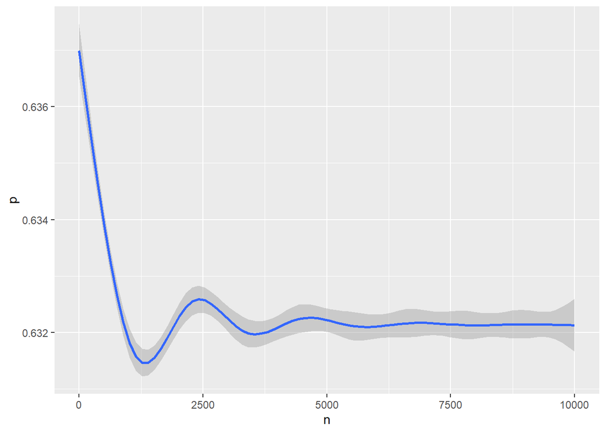

```r
x = 1:10000
y = 1 - (1 - 1/x)^x

data = data.frame(
  n=x,
  p=y
)

ggplot(data=data, aes(x=n, y=p)) + geom_smooth()
```

4. Properties of Bootstrap (Cont.)

g. It's wiggly. I thought it would approach 1 as n goes to infinity, but clearly it roughly approaches 0.6321. Let's solve this limit for fun.  
lim(n->inf) 1 - (1 - 1/n)^n = L  
1 - L = (1 - 1/n)^n  
ln(1 - L) = ln((1 - 1/n)^n)  
ln(1 - L) = nln(1 - 1/n)  
ln(1 - L) = ln(1 - 1/n)/n^-1  
ln(1 - L) = (1/(1-1/n) * --1/n^2) / (-1/n^2)  
ln(1 - L) = -1/(1-1/n) = -1  
1 - L = e^-1  
L = 1 - e^-1 = 0.6321205588...

```r
results <- rep(NA, 10000)
for(i in 1:10000){
results[i] <- sum(sample(1:100, rep=TRUE) == 5) > 0
}
mean(results)
```

```
## [1] 0.632
```

4. Properties of Bootstrap (Cont.)

h. Our numerical result is extremly similar to our analytical result. Pretty neat.

```r
options(warn=1)
```